# Fabi’s Week 9 Homework

Author

Fabiola Gonzalez Zamora

### Week 9 Homework Instructions

- Make a plot where at least one axis is a factor in a meaningful order
- `intertidal.csv` and `intertidal_latitude.csv`
- May need to use string-cleaning skills
  - Check out [{janitor} package](https://sfirke.github.io/janitor/articles/janitor.html) to tidy column names
- *Tide height*: must go Low, Mid, High on the plot
- *Site*: must go in order of latitude (N to S or S to N)

```r
library(tidyverse)
library(here)
library(ggplot2)
library(dplyr)
library(here)
library(beepr)
library(peRReo)
library(gm)
library(janitor)
```

### Cleaning Intertidal Data

- `clean_names()` standardizes headers, fixes the funky spaces
- `str_extract()` pulls the tide, strips junk
- Format tide order explicitly using `factor(levels())`

```r
# Read Data
intertidal_raw <- read_csv(here("Week_09", "Data", "intertidaldata.csv"), show_col_types = FALSE)


# Make tide levels
tide_levels <- c("Low", "Mid", "High")

# Clean data
intertidal <- intertidal_raw |>
  clean_names() |> # Bare Rock = bare_rock, Mussels = mussels
  mutate(
    quadrat = str_extract(quadrat, "Low|Mid|High"), # str_extract pulls values of interest, strips extra spaces
    quadrat = factor(quadrat, levels = tide_levels)
  )

# Let's check my work real quick
sum(is.na(intertidal$quadrat)) # [1] 0
```

```
[1] 0
```

```r
levels(intertidal$quadrat) # [1] "Low"  "Mid"  "High"
```

```
[1] "Low"  "Mid"  "High"
```

### Joining Latitude Data

- Files share site names, so we can use `left_join()`
- Used `fct_reorder()` to format the site order

```r
# Read data
latitude_raw   <- read_csv(here("Week_09", "Data", "intertidaldata_latitude.csv"), show_col_types = FALSE)

latitude <- latitude_raw |>
  clean_names() |>
  mutate(site = fct_reorder(site, latitude, .desc = TRUE))

levels(latitude$site) # lil sanity check
```

```
 [1] "Starfish Point"   "Cape Meares"      "Fogarty Creek"    "Cape Arago"
 [5] "Pyramid Point"    "Point St. George" "Bodega"           "Cambria"
 [9] "Hazards"          "Shell Beach"      "Carpenteria"      "Little Corona"
[13] "Crystal Cove"     "Dana Point"       "Scripps"
```

```r
intertidal <- intertidal |>
  left_join(latitude, by = "site") |>
  mutate(site = fct_reorder(site, latitude, .desc = TRUE))

# fct_reorder() sets level by another variable
# .desc = TRUE puts northern sites first N -> S

levels(intertidal$site) # Check order
```

```
 [1] "Starfish Point"   "Cape Meares"      "Fogarty Creek"    "Cape Arago"
 [5] "Pyramid Point"    "Point St. George" "Bodega"           "Cambria"
 [9] "Hazards"          "Shell Beach"      "Carpenteria"      "Little Corona"
[13] "Crystal Cove"     "Dana Point"       "Scripps"
```

```r
# [1] "Starfish Point"  = 47.7 N
# [15] "Scripps"        = 32.9 N
```

### Cover by Tide Height

In Figure 1, `Tide Height` is on the x-axis in Low -> Mid -> High order, and each `taxon` has its respective % cover plotted

- `Low` dominated by algae (64%)
- `Mid` dominated by mussels (41%)
- `High` dominated by small barnacles (37%)

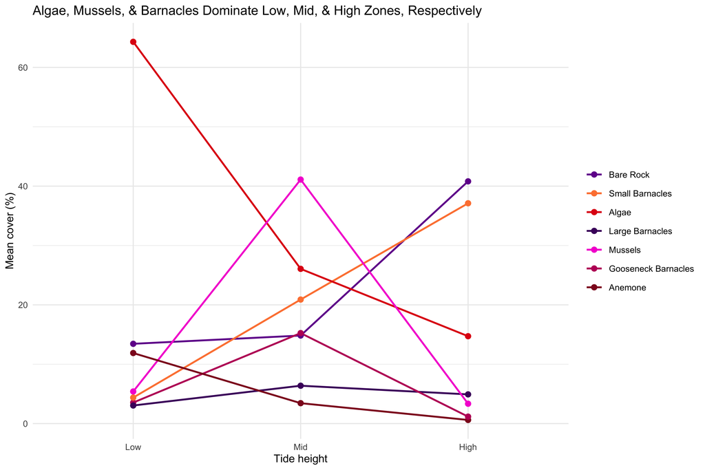

Figure 1: Mean Percent Cover by Tide Height, Averaged across 15 sites

```r
# Need to conver wide to long, each taxon and percent_cover become individual observations (rows) for better plotting
cover <- intertidal |>
  select(site, transect, quadrat, latitude,
         bare_rock:anemone) |> # Lil shortcut to select adjacent columns
  pivot_longer(bare_rock:anemone,
               names_to = "taxon", values_to = "percent_cover")

# Now need to summarize percent coverage
number_colors <- cover |>
  distinct(taxon) |>
  nrow()

# Make the palette
pal <- latin_palette(
    "natti",
    number_colors)

dazone <- cover |>
  group_by(quadrat, taxon) |>
  summarise(
    mean_cover = mean(percent_cover, na.rm = TRUE),
    .groups = "drop") |>
  mutate(
    taxon = str_replace_all(taxon, "_", " ") |> # This replaces all matches -> "_" get replaced as " "
      str_to_title(), # Converts to title case
    taxon = fct_reorder2(taxon, as.integer(quadrat), mean_cover) # orders levels by the second variable’s value at the largest value of the first
  )

# Time for plot!
algeez <- ggplot(dazone,
                 aes(x = quadrat,
                     y = mean_cover,
                     color = taxon,
                     group = taxon)) + # Need since geom_line won't cross discrete axis without it
  geom_line(linewidth = 0.8) +
  geom_point(size = 2.1) +
  scale_color_manual(
    values = pal) +
  labs(
    title = "Algae, Mussels, & Barnacles Dominate Low, Mid, & High Zones, Respectively",
    x = "Tide height",
    y = "Mean cover (%)",
    color = NULL
  ) +
theme_minimal(base_size = 10)

algeez

ggsave(here("Week_09", "Output", "mean_cover_per_site.png"),
       plot = algeez)
```

### Site by Taxon, Faceted by Tide Height

In Figure 2, I used both ordering, with`sites` ordered by latitude, and facets on x ordered Low -> Mid -> High

- Used `geom_tile` to create a heat map to visualize `site` against `tide` and its relative `% cover` represented by color intensity

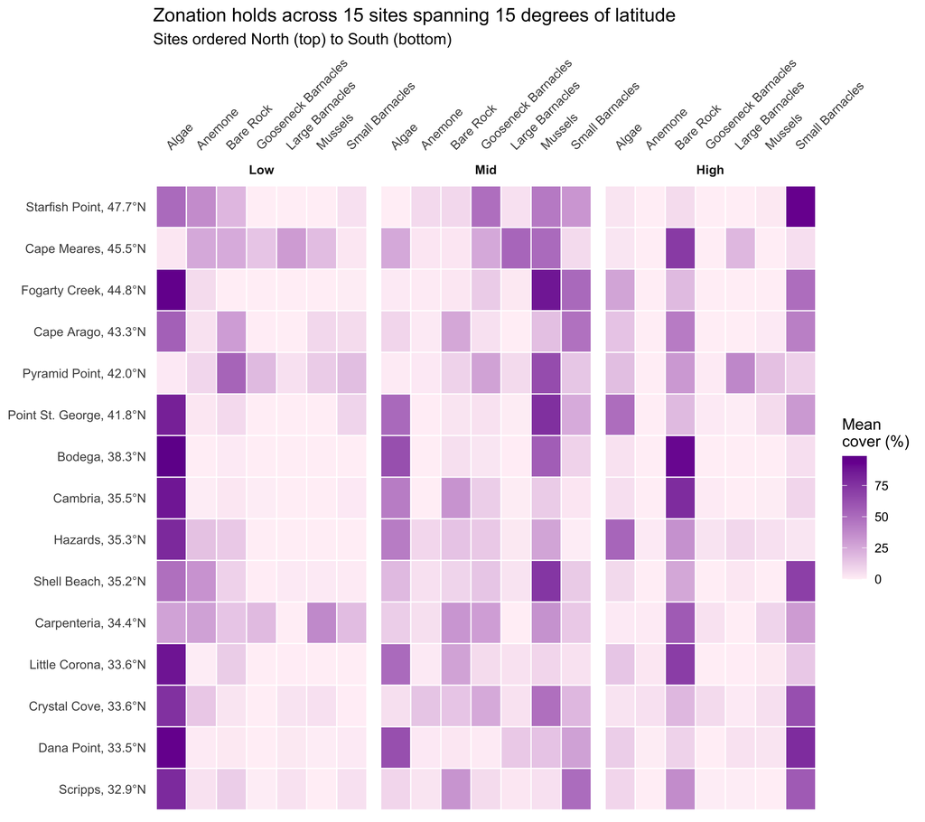

Figure 2: Mean percent cover by site and taxon, faceted by tide heigh

```r
site_zone <- cover |>
  group_by(site, latitude, quadrat, taxon) |> # group_by() and summarise() preserve factor levels
  summarise(
    mean_cover = mean(percent_cover, na.rm = TRUE),
    .groups = "drop") |>
  mutate(
    taxon = str_replace_all(taxon, "_", " ") |> # Removes "_" with a space for cleaner labels
      str_to_title(), # Capitalizes first word here
    site_label = fct_reorder(
      paste0(site, ", ", sprintf("%.1f", latitude), "\u00B0N"),
      latitude) # want to make sure the factor is ordered by latitude
  )

# sprintf("%.1f", latitude): rounds the latitude to  one decimal place and turns it into a string (e.g., 45.32 becomes "45.3")
# Unicode escape sequence for the degree symbol (°), followed by "N" for North


zonegrid <- ggplot(site_zone,
                   aes(
                     x = taxon,
                     y = site_label,
                     fill = mean_cover)) +
  geom_tile(color = "white",
             linewidth = 0.4) +
  facet_wrap(~ quadrat) + # Facets inherit the Low -> Mid -> High facotr order
  scale_fill_gradient(low = "#FFF1F7", # Sequential single-hue scale: darkness rises with cover
                      high = "#72069A",
                      name = "Mean\ncover (%)") + # Stack "Mean" and "cover (%)" with \n
  scale_x_discrete(position = "top") +
  labs(
    title = "Zonation holds across 15 sites spanning 15 degrees of latitude",
    x = NULL,
    y = NULL,
    subtitle = "Sites ordered North (top) to South (bottom)"
  ) +
  theme_minimal(base_size = 11) +
  theme(
    panel.grid  = element_blank(),
    axis.text.x = element_text(angle = 45,
                               hjust = 0,
                               vjust = 0),
    strip.text  = element_text(face = "bold")
  )

zonegrid

ggsave(here("Week_09", "Output", "cover_heat_map.png"),
       plot = zonegrid)
```